# Panel Data in R

```r
library(foreign)
library(plm)
if (loadNew) {
  Panel <-read.dta("http://dss.princeton.edu/training/Panel101.dta")
  save(Panel, file="data/Panel101.rda")
} else {
  load("data/Panel101.rda")
}

head(Panel)
```

```
##   country year           y y_bin        x1         x2          x3
## 1       A 1990  1342787840     1 0.2779036 -1.1079559  0.28255358
## 2       A 1991 -1899660544     0 0.3206847 -0.9487200  0.49253848
## 3       A 1992   -11234363     0 0.3634657 -0.7894840  0.70252335
## 4       A 1993  2645775360     1 0.2461440 -0.8855330 -0.09439092
## 5       A 1994  3008334848     1 0.4246230 -0.7297683  0.94613063
## 6       A 1995  3229574144     1 0.4772141 -0.7232460  1.02968037
##     opinion
## 1 Str agree
## 2     Disag
## 3     Disag
## 4     Disag
## 5     Disag
## 6 Str agree
```

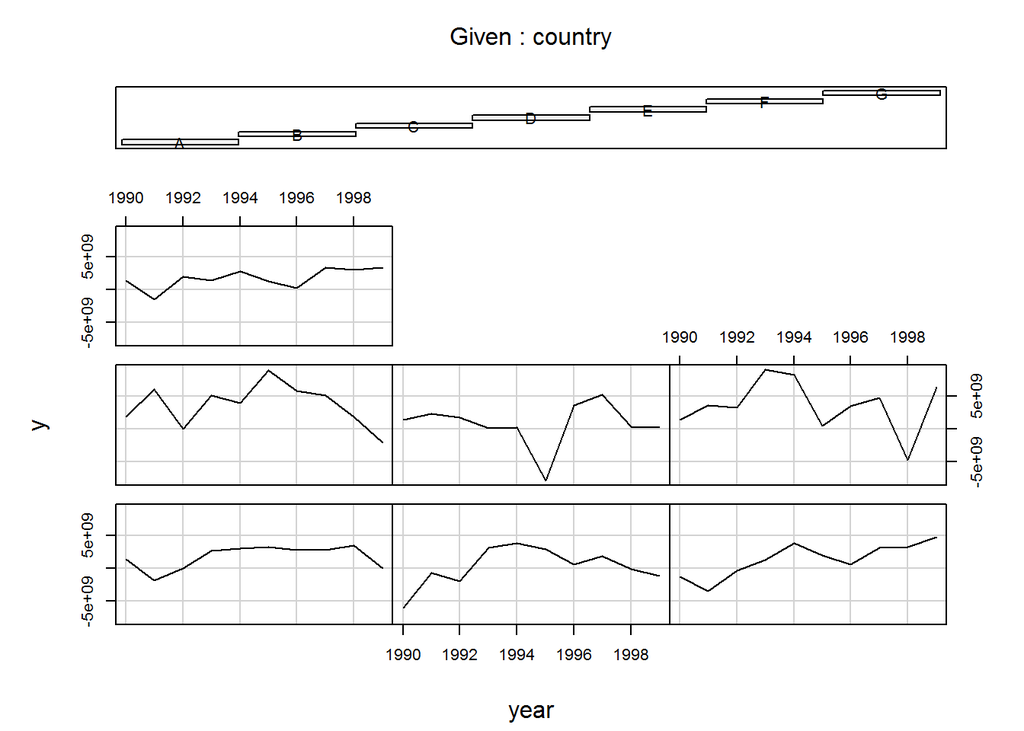

```r
coplot(y ~ year|country, type="l", data=Panel) # Lines
```

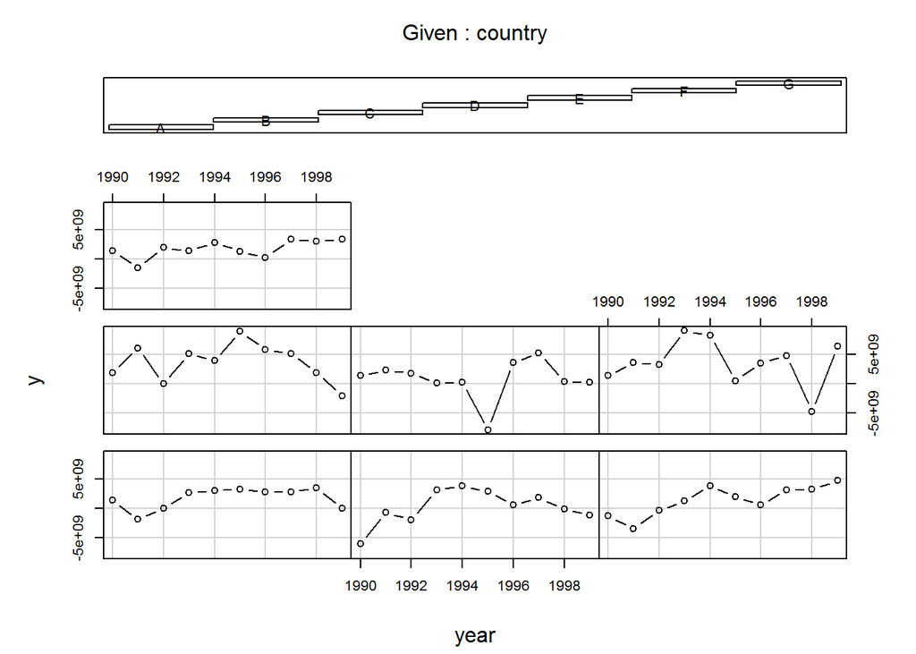

```r
coplot(y ~ year|country, type="b", data=Panel)
```

## Fixed Effects Model

```r
ols<-lm(y ~ x1, data=Panel)
summary(ols)
```

```
##
## Call:
## lm(formula = y ~ x1, data = Panel)
##
## Residuals:
##        Min         1Q     Median         3Q        Max
## -9.546e+09 -1.578e+09  1.554e+08  1.422e+09  7.183e+09
##
## Coefficients:
##              Estimate Std. Error t value Pr(>|t|)
## (Intercept) 1.524e+09  6.211e+08   2.454   0.0167 *
## x1          4.950e+08  7.789e+08   0.636   0.5272
## ---
## Signif. codes:  0 '***' 0.001 '**' 0.01 '*' 0.05 '.' 0.1 ' ' 1
##
## Residual standard error: 3.028e+09 on 68 degrees of freedom
## Multiple R-squared:  0.005905,   Adjusted R-squared:  -0.008714
## F-statistic: 0.4039 on 1 and 68 DF,  p-value: 0.5272
```

### Dummy Model

```r
fixed.dum <-lm(y ~ x1 + factor(country) -1, data=Panel)
summary(fixed.dum)
```

```
##
## Call:
## lm(formula = y ~ x1 + factor(country) - 1, data = Panel)
##
## Residuals:
##        Min         1Q     Median         3Q        Max
## -8.634e+09 -9.697e+08  5.405e+08  1.386e+09  5.612e+09
##
## Coefficients:
##                    Estimate Std. Error t value Pr(>|t|)
## x1                2.476e+09  1.107e+09   2.237  0.02889 *
## factor(country)A  8.805e+08  9.618e+08   0.916  0.36347
## factor(country)B -1.058e+09  1.051e+09  -1.006  0.31811
## factor(country)C -1.723e+09  1.632e+09  -1.056  0.29508
## factor(country)D  3.163e+09  9.095e+08   3.478  0.00093 ***
## factor(country)E -6.026e+08  1.064e+09  -0.566  0.57329
## factor(country)F  2.011e+09  1.123e+09   1.791  0.07821 .
## factor(country)G -9.847e+08  1.493e+09  -0.660  0.51190
## ---
## Signif. codes:  0 '***' 0.001 '**' 0.01 '*' 0.05 '.' 0.1 ' ' 1
##
## Residual standard error: 2.796e+09 on 62 degrees of freedom
## Multiple R-squared:  0.4402, Adjusted R-squared:  0.368
## F-statistic: 6.095 on 8 and 62 DF,  p-value: 8.892e-06
```

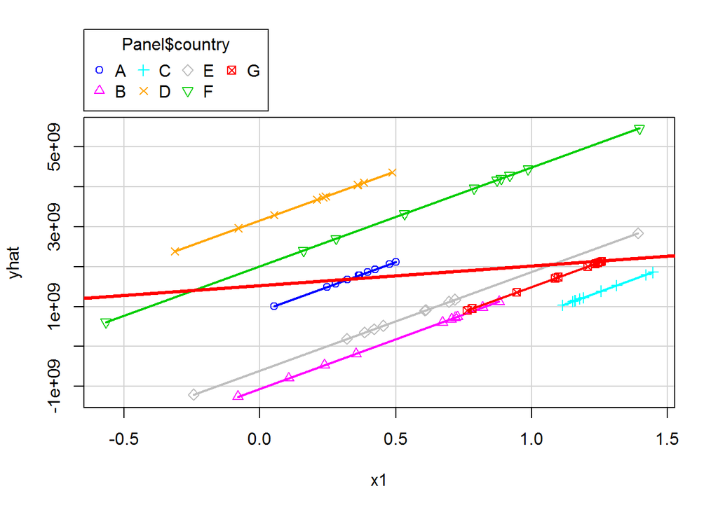

```r
yhat<-fixed.dum$fitted
library(car)
 scatterplot(yhat~Panel$x1|Panel$country, boxplots=FALSE, xlab="x1", ylab="yhat",smooth=FALSE)
 abline(lm(Panel$y~Panel$x1),lwd=3, col="red")
```

### plm library

```r
fixed <-plm(y~ x1, data=Panel, index=c("country", "year"), model="within")
summary(fixed)
```

```
## Oneway (individual) effect Within Model
##
## Call:
## plm(formula = y ~ x1, data = Panel, model = "within", index = c("country",
##     "year"))
##
## Balanced Panel: n = 7, T = 10, N = 70
##
## Residuals:
##      Min.   1st Qu.    Median      Mean   3rd Qu.      Max.
## -8.63e+09 -9.70e+08  5.40e+08  0.00e+00  1.39e+09  5.61e+09
##
## Coefficients:
##      Estimate Std. Error t-value Pr(>|t|)
## x1 2475617827 1106675594   2.237  0.02889 *
## ---
## Signif. codes:  0 '***' 0.001 '**' 0.01 '*' 0.05 '.' 0.1 ' ' 1
##
## Total Sum of Squares:    5.2364e+20
## Residual Sum of Squares: 4.8454e+20
## R-Squared:      0.074684
## Adj. R-Squared: -0.029788
## F-statistic: 5.00411 on 1 and 62 DF, p-value: 0.028892
```

Display the fixed effects (constants for each country)

```r
fixef(fixed)
```

```
##           A           B           C           D           E           F
##   880542404 -1057858363 -1722810755  3162826897  -602622000  2010731793
##           G
##  -984717493
```

Testing for fixed effects, null: OLS better than fixed

```r
pFtest(fixed, ols)
```

```
##
##  F test for individual effects
##
## data:  y ~ x1
## F = 2.9655, df1 = 6, df2 = 62, p-value = 0.01307
## alternative hypothesis: significant effects
```

## RANDOM-EFFECTS MODEL(Random Intercept, Partial Pooling Model)

```r
random <-plm(y ~ x1, data=Panel, index=c("country", "year"), model="random")
summary(random)
```

```
## Oneway (individual) effect Random Effect Model
##    (Swamy-Arora's transformation)
##
## Call:
## plm(formula = y ~ x1, data = Panel, model = "random", index = c("country",
##     "year"))
##
## Balanced Panel: n = 7, T = 10, N = 70
##
## Effects:
##                     var   std.dev share
## idiosyncratic 7.815e+18 2.796e+09 0.873
## individual    1.133e+18 1.065e+09 0.127
## theta: 0.3611
##
## Residuals:
##      Min.   1st Qu.    Median      Mean   3rd Qu.      Max.
## -8.94e+09 -1.51e+09  2.82e+08  0.00e+00  1.56e+09  6.63e+09
##
## Coefficients:
##               Estimate Std. Error t-value Pr(>|t|)
## (Intercept) 1037014284  790626206  1.3116   0.1941
## x1          1247001782  902145601  1.3823   0.1714
##
## Total Sum of Squares:    5.6595e+20
## Residual Sum of Squares: 5.5048e+20
## R-Squared:      0.02733
## Adj. R-Squared: 0.013026
## F-statistic: 1.91065 on 1 and 68 DF, p-value: 0.17141
```

Interpretation of the coefficients is tricky since they include both the within-entity and between-entity effects. In the case of TSCS data represents the average effect of Xover Ywhen Xchanges across time and between countries by one unit.

### Hausman test

To decide between fixed or random effects you can run a Hausman test where the null hypothesis is that the preferred model is random effects vs. the alternative the fixed effects (see Green, 2008, chapter 9). It basically tests whether the unique errors (ui) are correlated with the regressors, the null hypothesis is they are not. Run a fixed effects model and save the estimates, then run a random model and save the estimates, then perform the test. If the p-value is significant (for example <0.05) then use fixed effects, if not use random effects.

```r
phtest(fixed, random)
```

```
##
##  Hausman Test
##
## data:  y ~ x1
## chisq = 3.674, df = 1, p-value = 0.05527
## alternative hypothesis: one model is inconsistent
```

### Other Tests

Testing time-fixed effects. The null is that no time-fixed effects are needed.

```r
fixed.time<-plm(y ~ x1 + factor(year), data=Panel, index=c("country", "year"), model="within")
summary(fixed.time)
```

```
## Oneway (individual) effect Within Model
##
## Call:
## plm(formula = y ~ x1 + factor(year), data = Panel, model = "within",
##     index = c("country", "year"))
##
## Balanced Panel: n = 7, T = 10, N = 70
##
## Residuals:
##      Min.   1st Qu.    Median      Mean   3rd Qu.      Max.
## -7.92e+09 -1.05e+09 -1.40e+08  0.00e+00  1.63e+09  5.49e+09
##
## Coefficients:
##                    Estimate Std. Error t-value Pr(>|t|)
## x1               1389050354 1319849567  1.0524  0.29738
## factor(year)1991  296381559 1503368528  0.1971  0.84447
## factor(year)1992  145369666 1547226548  0.0940  0.92550
## factor(year)1993 2874386795 1503862554  1.9113  0.06138 .
## factor(year)1994 2848156288 1661498927  1.7142  0.09233 .
## factor(year)1995  973941306 1567245748  0.6214  0.53698
## factor(year)1996 1672812557 1631539254  1.0253  0.30988
## factor(year)1997 2991770063 1627062032  1.8388  0.07156 .
## factor(year)1998  367463593 1587924445  0.2314  0.81789
## factor(year)1999 1258751933 1512397632  0.8323  0.40898
## ---
## Signif. codes:  0 '***' 0.001 '**' 0.01 '*' 0.05 '.' 0.1 ' ' 1
##
## Total Sum of Squares:    5.2364e+20
## Residual Sum of Squares: 4.0201e+20
## R-Squared:      0.23229
## Adj. R-Squared: 0.00052851
## F-statistic: 1.60365 on 10 and 53 DF, p-value: 0.13113
```

```r
pFtest(fixed.time, fixed)
```

```
##
##  F test for individual effects
##
## data:  y ~ x1 + factor(year)
## F = 1.209, df1 = 9, df2 = 53, p-value = 0.3094
## alternative hypothesis: significant effects
```

### Testing for random effects

Breusch-Pagan Lagrange Multiplier for random effects. Null is no panel effect (i.e. OLS better).

```r
pool <-plm(y ~ x1, data=Panel, index=c("country", "year"), model="pooling")
summary(pool)
```

```
## Pooling Model
##
## Call:
## plm(formula = y ~ x1, data = Panel, model = "pooling", index = c("country",
##     "year"))
##
## Balanced Panel: n = 7, T = 10, N = 70
##
## Residuals:
##      Min.   1st Qu.    Median      Mean   3rd Qu.      Max.
## -9.55e+09 -1.58e+09  1.55e+08  0.00e+00  1.42e+09  7.18e+09
##
## Coefficients:
##               Estimate Std. Error t-value Pr(>|t|)
## (Intercept) 1524319070  621072624  2.4543  0.01668 *
## x1           494988914  778861261  0.6355  0.52722
## ---
## Signif. codes:  0 '***' 0.001 '**' 0.01 '*' 0.05 '.' 0.1 ' ' 1
##
## Total Sum of Squares:    6.2729e+20
## Residual Sum of Squares: 6.2359e+20
## R-Squared:      0.0059046
## Adj. R-Squared: -0.0087145
## F-statistic: 0.403897 on 1 and 68 DF, p-value: 0.52722
```

```r
plmtest(pool, type=c("bp"))
```

```
##
##  Lagrange Multiplier Test - (Breusch-Pagan) for balanced panels
##
## data:  y ~ x1
## chisq = 2.6692, df = 1, p-value = 0.1023
## alternative hypothesis: significant effects
```

### Testing for serial correlation

Serial correlation tests apply to macro panels with long time series. Not a problem in micro panels (with very few years). The null is that there is not serial correlation.

```r
pbgtest(fixed)
```

```
##
##  Breusch-Godfrey/Wooldridge test for serial correlation in panel
##  models
##
## data:  y ~ x1
## chisq = 14.137, df = 10, p-value = 0.1668
## alternative hypothesis: serial correlation in idiosyncratic errors
```

No serial correlation

### Testing for unit roots/stationarity

```r
Panel.set<-plm.data(Panel, index = c("country", "year"))
library(tseries)
adf.test(Panel.set$y, k=2)
```

```
##
##  Augmented Dickey-Fuller Test
##
## data:  Panel.set$y
## Dickey-Fuller = -3.9051, Lag order = 2, p-value = 0.0191
## alternative hypothesis: stationary
```

### Testing for heteroskedasticity

The null hypothesis for the Breusch-Pagan test is homoskedasticity.

Presence of heteroskedasticity If heteroskedasticity is detected you can use robust covariance matrix to account for it.

```r
library(lmtest)
 bptest(y ~ x1 + factor(country), data = Panel, studentize=F)
```

```
##
##  Breusch-Pagan test
##
## data:  y ~ x1 + factor(country)
## BP = 14.606, df = 7, p-value = 0.04139
```